# 53-randomforest-performance

In this notebook, we will look at the performance of the randomForest modeling strategy.

**Note that prior to running this notebook 46-randomForest-modeling must already have been run to generate new results. Otherwise, load using the provided data loading chunk.**

# 1 Load Saved Data

```r
move_model_info('rf', 'load');
```

# 2 Selected Model Performance Evaluation

## 2.1 Cross validation metrics from best model

Let’s first evaluate the performance using the cross-validation metrics from before. However, here, we’ll only look at the best model.

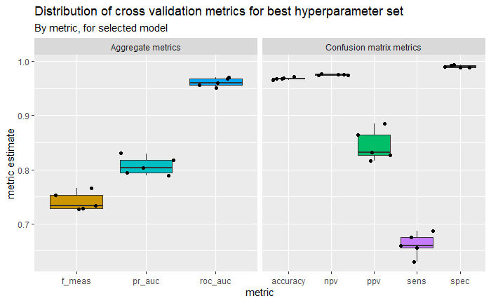

```r
#get best rf metrics
best_rf_fold_metrics <- calculate_best_performance_metrics(rf_fold_metrics, best_rf_params)
```

```r
best_rf_fold_metrics %>%
  group_by(.metric) %>%
  summarize(overall_perf = mean(.estimate))
```

|  | .metric | overall_perf |
| --- | --- | --- |
| 1 | accuracy | 0.9686080 |
| 2 | f_meas | 0.7415706 |
| 3 | npv | 0.9756537 |
| 4 | ppv | 0.8449235 |
| 5 | pr_auc | 0.8067746 |
| 6 | roc_auc | 0.9611637 |
| 7 | sens | 0.6613058 |
| 8 | spec | 0.9910418 |

Here we can see the overall performance of the best model during its cross validation phase. This performance mirrors the behavior of the previous cross-validation metrics. The ROC AUC is again looking very stable, while the PR AUC leaves a bit to be desired. The metrics which rely on threshold are very stable and performant for calculations which rely or focus heavily on the class of disinterest. On the other hand, the sensitivity and ppv leave much to be desired. Again, implementing a tailored thresholding strategy here will allow for better use of the model.

# 3 Performance on training data as a whole

Here, we look at the confusion matrix for the entire training set as well as computations from the confusion matrix.

```r
#get prediction class and probabilities
rf_training_preds <- get_prediction_dataframes(rf_final_fit, train_data)
```

## 3.1 ROC Curve

Let’s start by looking at an ROC curve.

```
    === AUCs ===

     Model name Dataset ID Curve type       AUC
   1     Model1          1        ROC 0.9999980
   2     Model1          1        PRC 0.9999724

    === Input data ===

     Model name Dataset ID # of negatives # of positives
   1     Model1          1          31377           2294
```

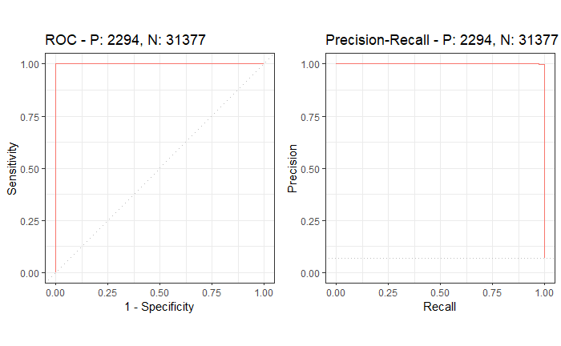

```r
plot_performance_curves(rf_training_preds)
```

These are outrageously good ROC/PRC curves. Suspiciously good.

## 3.2 Interpretating probability thresholds

In this section, we gain insight into what we should do for thresholding and our expectations surrounding it.

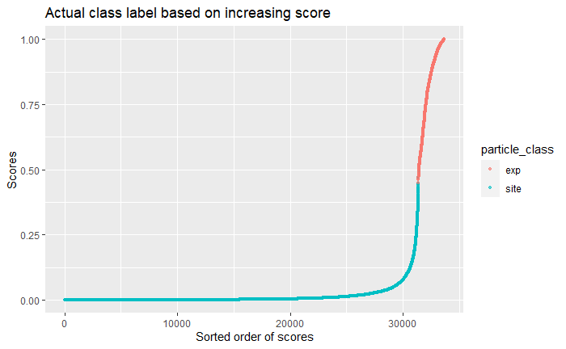

```r
plot_label_by_score(rf_training_preds)
```

### 3.2.1 Calibration curve

In this section, we look at the calibration curve of the model. Calibration curves closer to the 45 degree line demonstrate better calibrated models (e.g., where scores can be interpreted as probabilities).

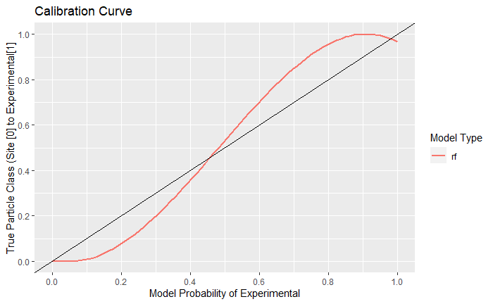

```r
plot_calibration_curve(rf_training_preds, mdl_name='rf')
```

This model seems to demonstrate a traditional s-shaped calibration curve, meaning that it overestimates probabilities under 0.5 and underestimates those for >0.5. This model may benefit from additional score adjustment strategies.

## 3.3 Applied probability thresholds

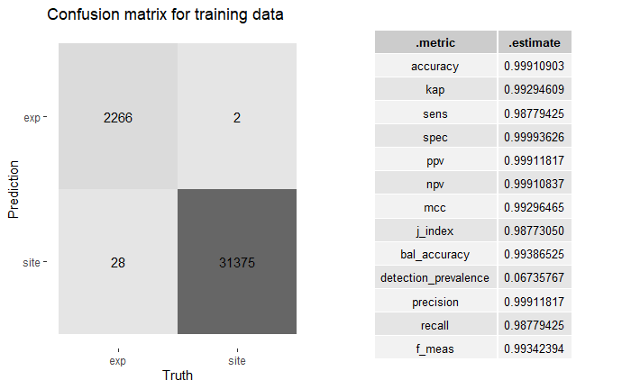

```r
#calculate confusion matrix
rf_conf_mat <- calculate_confusion_matrix(rf_training_preds)
```

# 4 Explaining the model

## 4.1 Variable imporance

What parameters are contributing most strongly to the classification? Do we see evidence of data snooping? Let’s take a look! Note that this cell for random forest takes a while to run.

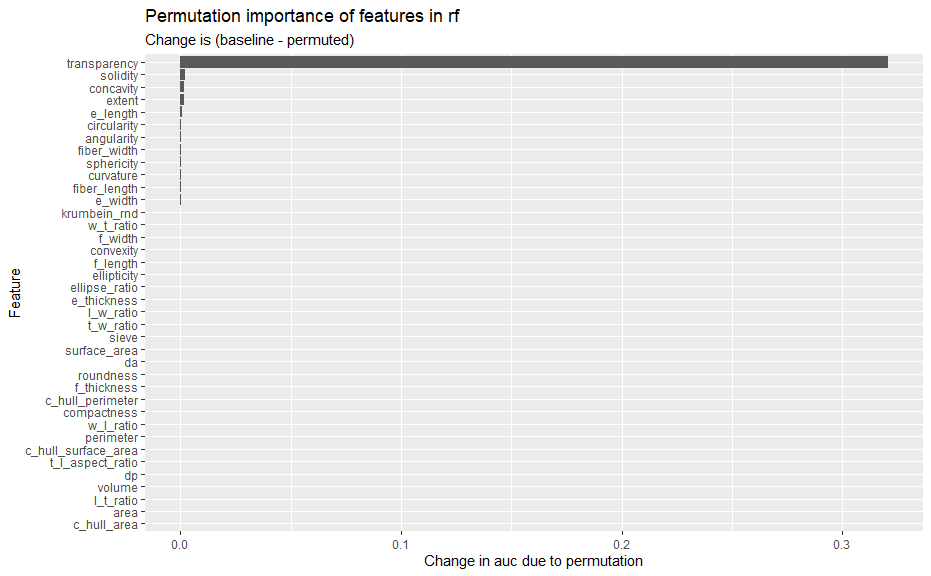

```r
rf_vip <- plot_variable_importance(rf_final_fit, assessment_data=train_data, mdl_name = 'rf', positive_class='exp')
```

# 5 Save markdown file

```r
fs::file_copy('53-randomforest-performance.nb.html', './html_results/53-randomforest-performance.nb.html', overwrite=TRUE)
```